# Using Predictive Analytics to Understand the Impacts of COVID-19 on Unemployment in the U.S.

Sylvia Brown, Pierina Forastieri, Julia Buschmann, Marlyn Bruno

2022-05-06

### Introduction

While the COVID-19 pandemic started as a public health crisis, households in the U.S. and other countries experienced the pandemic as a accumulated housing, labor, and financial crises as well. Given the dramatic and often unpredictable impact of the pandemic on the labor force, determining how to predict the economic impact of future, similar events is of interest. Being able to predict whether an individual experiences unemployment as a result of the pandemic, for example, may be useful in planning targeted future interventions during such unusual times.

### About This Project

The primary contribution of our project is to generate a model to predict unemployment using data before and during the pandemic (2019 and 2020).

To better understand our modeling data, we develop several data visualizations using data from the Current Population Survey (CPS) ASEC supplements (2019-2021) to see how unemployment and employment varies by age group and state. We then identify variables used to include as predictors in our predictive model and use Principal Components Analysis (PCA) to generate uncorrelated components to capture a portion of the variance of the original predictors. Using both our original predictors and the resulting PCs, we generate a random forest model and a logistic regression model trained on ASEC data from 2019 and 2020 to predict whether an individual was employed. We then implement the best model (selected by identifying the model with the highest area under the ROC curve) on data from 2021 to test its accuracy in predicting whether an individual was employed in the second year of the pandemic. We also test the model on a subset of the population (immigrants) to see if the model, which was developed with both immigrants and non-immigrants, is generalizable to only immigrants. With a model like this, we can predict the employment status for future individuals for whom we have data on their characteristics (e.g., income, state, type of health insurance) so that when a future pandemic or natural disaster happens, policymakers will be better equipped to understand who to target support towards. This model can therefore support an informed approach to outreach, so that governments or social service agencies can focus their resources with targeted outreach to the individuals that are predicted to be unemployed after the start of the pandemic.

### Data Sources

For this analysis, we employ the [Annual Social and Economic Supplemental (ASEC)](https://www.census.gov/programs-surveys/saipe/guidance/model-input-data/cpsasec.html) of the Current Population Survey (CPS), also known as the March Supplemental survey. The CPS ASEC survey is conducted annually, mostly in March, during a one month window of data collection. The survey asks participants a series of questions that are similar to the CPS survey, but also asks about topics related to income, earnings, poverty, and the foreign-born population.[^1] Our project uses the March Supplemental survey results from 2019, 2020, and 2021. We accessed these data through Integrated Public Use Microdata Series (IPUMS) at the University of Minnesota.[^2]

To view further details of the project, visit the project’s public GitHub repository [here](https://github.com/sbrown5x/Final_Project/).

Below we load in our libraries.

```r
# Add libraries
library(formattable)
library(ggalt)
library(ggplot2)
library(haven)
library(ipumsr)
library(labelled)
library(patchwork)
library(sf)
library(sjlabelled)
library(srvyr)
library(tidyverse)
library(tigris)
```

Next, we read in the ASEC data, recoding missing values as NAs, recoding variables as dummies, dropping extraneous variables, filtering out people in the armed forces, and selecting only adults aged 18 to 65 (inclusive). We also create two new variables: `employed`, which indicates whether a respondent is unemployed or employed and is NA for anyone outside of the labor force; and `immigrant`, which is a dummy variable coded as 1 for people born in the U.S. and 0 for people born in the U.S. outlying territories (e.g., PR, Guam), naturalized citiens, non-citizens, and people born abroad of American parents. Finally, we create the data tables that we will use throughout our analysis.

```r
ddi <- read_ipums_ddi("data/cps_00004.xml")
data <- read_ipums_micro(ddi) %>%
  janitor::clean_names()

cps_svy <- data %>%
  # Filter  out people in armed forces
  filter(empstat != 1) %>%
  filter(age >= 18 & age < 66) %>%
  # Filter out minors; leave only adults
  mutate(employed = case_when(
    empstat == 10 | empstat == 12 ~ 1,
    empstat == 21 | empstat == 22 ~ 0,
    TRUE ~ NA_real_
  )) %>%
  # Recode variables as dummies (0,1)
  mutate_at(vars(offpov, himcarenw, caidnw, anycovly, prvtcovnw, grpcovnw, mrkcovnw, mrkscovnw, mrkucovnw, inhcovnw, sex), list(~ case_when(
    . == 2 ~ 1,
    . == 1 ~ 0,
    TRUE ~ NA_real_
  ))) %>%
  # Turn values coded as missing into NAs
  mutate(unitsstr = case_when(
    unitsstr == 00 ~ NA_real_,
    TRUE ~ as.numeric(unitsstr)
  )) %>%
  mutate(region = case_when(
    region == 97 ~ NA_real_,
    TRUE ~ as.numeric(region)
  )) %>%
  mutate(metro = case_when(
    metro == 0 | metro >= 4 ~ NA_real_,
    TRUE ~ as.numeric(metro)
  )) %>%
  mutate(metarea = case_when(
    metarea >= 9997 ~ NA_real_,
    TRUE ~ as.numeric(metarea)
  )) %>%
  mutate(metfips = case_when(
    metfips >= 99998 ~ NA_real_,
    TRUE ~ as.numeric(metfips)
  )) %>%
  mutate(hhincome = case_when(
    hhincome == 9999999 ~ NA_real_,
    TRUE ~ as.numeric(hhincome)
  )) %>%
  mutate_at(vars(county, empstat, labforce, disabwrk), list(~ case_when(
    . == 0 ~ NA_real_,
    TRUE ~ as.numeric(.)
  ))) %>%
    mutate(educ = case_when(
    educ == 001 | educ == 999 ~ NA_real_,
    TRUE ~ as.numeric(educ)
  )) %>%
  mutate(ftotval = case_when(
    ftotval == 9999999999 ~ NA_real_,
    TRUE ~ as.numeric(ftotval)
  )) %>%
  mutate(inctot = case_when(
    inctot == 999999999 ~ NA_real_,
    TRUE ~ as.numeric(inctot)
  )) %>%
  mutate(incwelfr = case_when(
    incwelfr == 999999 ~ NA_real_,
    TRUE ~ incwelfr
  )) %>%
  mutate(incunemp = case_when(
    incunemp == 999999 ~ NA_real_,
    TRUE ~ as.numeric(incunemp)
  )) %>%
  mutate(ctccrd = case_when(
    ctccrd == 999999 ~ NA_real_,
    TRUE ~ as.numeric(ctccrd)
  )) %>%
  mutate(eitcred = case_when(
    eitcred == 9999 ~ NA_real_,
    TRUE ~ as.numeric(eitcred)
  )) %>%
  mutate(immigrant = case_when(
    citizen == 1 ~ 1,
    citizen >= 2 & citizen <= 5 ~ 0,
    TRUE ~ NA_real_
  )) %>%
    mutate(wksunem1 = case_when(
    wksunem1 == 99 ~ 0,
    TRUE ~ as.numeric(wksunem1)
  )) %>%
    mutate(wksunem2 = case_when(
    wksunem2 == 9 ~ 0,
    TRUE ~ as.numeric(wksunem2)
  )) %>%
  # Drop multi-state fips codes
  filter(statefip <= 56) %>%
  # Drop quality flags and variables we don't need
  select(-starts_with("q"), -asecwt, -month, -asecflag, -statecensus, -asecwth, -pernum, -cpsidp)

# Create a weighted survey object using COVID-19 ASEC weight
asec_allyears <- as_survey_design(cps_svy, weights = asecwtcvd)

# Create tibbles by year and tibbles with only immigrant population
asec2019 <- asec_allyears %>%
  filter(year == 2019)

asec2020 <- asec_allyears %>%
  filter(year == 2020)

asec2021 <- asec_allyears %>%
  filter(year == 2021)

asec_allyears_imm <- asec_allyears %>%
  filter(immigrant == 1)

asec2019_imm <- asec2019 %>%
  filter(immigrant == 1)

asec2020_imm <- asec2020 %>%
  filter(immigrant == 1)

asec2021_imm <- asec2021 %>%
  filter(immigrant == 1)
```

### Visualizing Employment

The first cases of COVID-19 appeared in the U.S. in early January, but it took several months for employees to feel the full effect of the pandemic on employment. As cases rose, businesses closed. Below we see the beginning of the impact that COVID-19 will come to have on the U.S. labor market. In March of 2020, there was a 1.5 percentage point increase in the unemployment rate from the year prior. A year later, we can see the sustained impact of the pandemic on the labor market and the repercussions from the Alpha variant, which peaked in January of 2021. In March 2021, the unemployment rate was about 2.5 percentage points higher than it was at the same time in 2019 (or about 1 percentage point higher than a year prior).

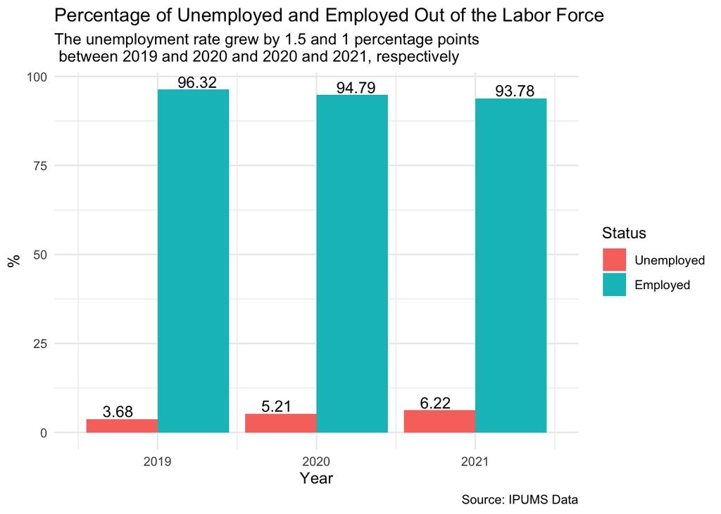

```r
# % Unemployed, employed, out of labor force in each
asec_allyears %>%
  drop_na(employed) %>%
  select(year, employed) %>%
  group_by(year, employed) %>%
  summarise(pct = survey_prop()*100) %>%
  ggplot(aes(x=year, y=pct, fill=factor(employed))) +
  geom_col(position="dodge") +
  labs(
    title = "Percentage of Unemployed and Employed Out of the Labor Force",
    subtitle = "The unemployment rate grew by 1.5 and 1 percentage points \n between 2019 and 2020 and 2020 and 2021, respectively",
    caption = "Source: IPUMS Data",
    x = "Year",
    y = "%",
    fill = "Status",
  ) +
  geom_text(aes(label = round(pct,2)),
                position = position_dodge(width = 1),
                color="black",vjust = -.2) +
  scale_fill_hue(labels = c("Unemployed", "Employed")) +
  theme(legend.title = element_blank()) +
  theme_minimal()
```

Overall, the share of employed people by age group remains relatively constant between 2019 and 2021. The most common age bracket among the unemployed was 18-24 year olds in all years included in our research (2019, 2020, and 2021), but their share of the unemployed decreased between 2019 and 2021.

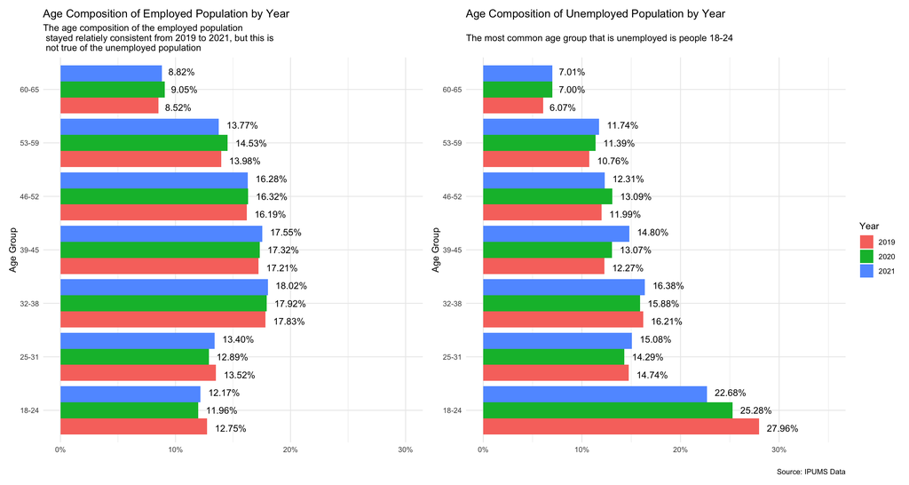

```r
# How does age differ between the employed and unemployed populations?
# Employed
employed_graph <- asec_allyears %>%
   mutate(
    # Create categories
    age_group = case_when(
      age > 17 & age <= 25 ~ "18-24",
      age > 24 & age <= 31 ~ "25-31",
      age > 21 & age <= 38 ~ "32-38",
      age > 38 & age <= 45 ~ "39-45",
      age > 45 & age <= 52 ~ "46-52",
      age > 52 & age <= 59 ~ "53-59",
      age > 59 & age <= 65 ~ "60-65"
    )) %>%
  drop_na(employed) %>%
  filter(employed == 1) %>%
  select(year, employed, age, age_group) %>%
  group_by(year, age_group) %>%
  summarise(cnt = n()) %>%
  mutate(freq = percent(cnt / sum(cnt))) %>%
  ggplot(aes(x=age_group, y=freq, fill=factor(year))) +
  geom_col(position="dodge", show.legend=FALSE) +
  geom_text(aes(age_group, label = freq), position = position_dodge(width = 1), hjust = -.25) +
  coord_flip() +
  scale_y_continuous(labels = scales::percent, limits = c(0,.3)) +
  labs(
    title = "Age Composition of Employed Population by Year",
    subtitle = "The age composition of the employed population \n stayed relatiely consistent from 2019 to 2021, but this is \n not true of the unemployed population",
    x = "Age Group",
    y = "",
    fill = "Year"
  ) +
  theme_minimal()


# Unemployed
unemployed_graph <- asec_allyears %>%
   mutate(
    # Create categories (18-24; 24-30; 31-37; 38-44, 45-51, 52-58, 58-64)
    age_group = case_when(
      age > 17 & age <= 25 ~ "18-24",
      age > 24 & age <= 31 ~ "25-31",
      age > 21 & age <= 38 ~ "32-38",
      age > 38 & age <= 45 ~ "39-45",
      age > 45 & age <= 52 ~ "46-52",
      age > 52 & age <= 59 ~ "53-59",
      age > 59 & age <= 65 ~ "60-65"
    )) %>%
  drop_na(employed) %>%
  filter(employed == 0) %>%
  select(year, employed, age, age_group) %>%
  group_by(year, age_group) %>%
  summarise(cnt = n()) %>%
  mutate(freq = percent(cnt / sum(cnt))) %>%
  ggplot(aes(x=age_group, y=freq, fill=factor(year))) +
  geom_col(position="dodge") +
  geom_text(aes(age_group, label = freq), position = position_dodge(width = 1), hjust = -.25) +
  coord_flip() +
  scale_y_continuous(labels = scales::percent, limits = c(0,.35)) +
  labs(
    title = "Age Composition of Unemployed Population by Year",
    subtitle = "The most common age group that is unemployed is people 18-24",
    caption = "Source: IPUMS Data",
    y = "",
    x = "Age Group",
    fill = "Year",
  ) +
  theme(legend.title = element_blank()) +
  theme_minimal()

employed_graph + unemployed_graph
```

### Understanding Unemployment at the State Level

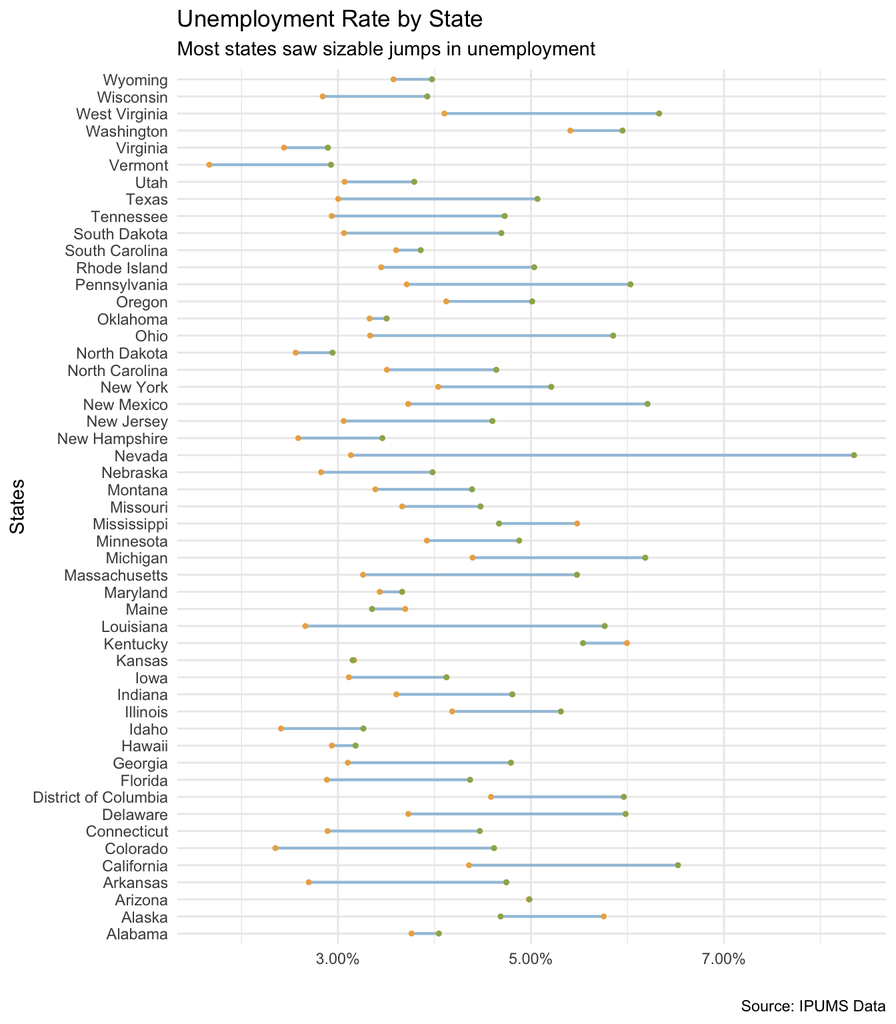

```r
# Dumbbell % unemployed by state between 2019 and 2020
status_bystate <- asec_allyears %>%
  drop_na(employed) %>%
  filter(year ==2019 | year == 2020) %>%
  select(year, employed, statefip) %>%
  group_by(year, statefip, employed) %>%
  summarise(cnt = n()) %>%
  mutate(freq = percent(cnt / sum(cnt)))

status_bystate %>%
  filter(employed == 0) %>%
  select(year, statefip, freq) %>%
  pivot_wider(names_from = year, values_from = freq) %>%
  ggplot(aes(x=`2019`, xend=`2020`, y=sjlabelled::as_label(statefip))) +
  geom_dumbbell(color="#a3c4dc",
                colour_x="#edae52",
                      colour_xend = "#9fb059",
                      size=0.75,
                      point.colour.l="#0e668b") +
  scale_x_continuous(label = percent)  +
  labs(
    title = "Unemployment Rate by State",
    subtitle = "Most states saw sizable jumps in unemployment",
    caption = "Source: IPUMS Data",
    x = "",
    y = "States",
  ) +
  theme_minimal()
```

We see significant variation in unemployment at the state level. In only March 2020, only two months after the first case hit the U.S., states were responding with stay-at-home orders and closing businesses were firing or laying off employees. One of the hardest-hit industries was leisure and hospitality, which is a core industry in Nevada and was quickly impacted when closures began.[^3]

```r
states <- tigris::states(cb = TRUE, progress_bar = FALSE) %>%
  filter(!STATEFP %in% c("78", "69", "66", "60", "72", "02", "15"))
```

```r
cps_svy_map <- cps_svy %>%
  as_survey_design(weights = asecwtcvd)
```

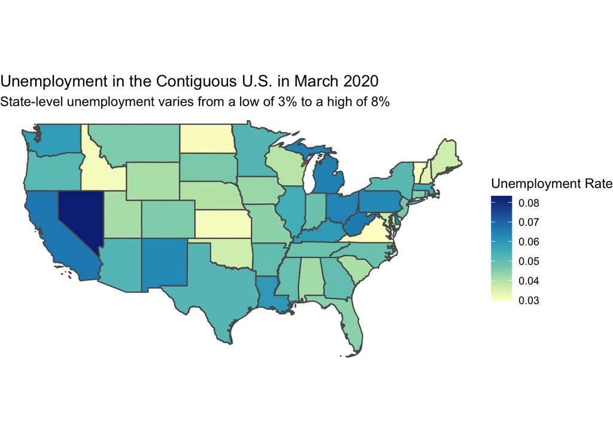

```r
# filtering cps_svy_map to the desired year, grouping to state, and getting the mean unemployment
df1 <- cps_svy_map %>%
  filter(year == 2020, !is.na(employed)) %>%
   group_by(statefip) %>%
   srvyr::summarize(emp_rate = survey_mean(1 - employed)) %>%
   rename(STATEFP = statefip)

# turning the state fip variable into a character, for compatibility before joining
df2 <- rapply(df1, as.character, how = "replace") %>%
   mutate(
     STATEFP = str_pad(STATEFP, width = 2, side = c("left"), pad = "0"))

# joining the df with unemployment to the shapefile
sf1 <- left_join(states, df2, by = "STATEFP")

# mapping unemployment for contiguous US
unemp_map <- df2 %>%
   ggplot() +
   geom_sf(data = sf1, mapping = aes(fill = as.numeric(emp_rate))) +
   scale_fill_distiller(direction = 1, name = "Unemployment Rate", palette = "YlGnBu") +
   theme_void() +
   labs(title = "Unemployment in the Contiguous U.S. in March 2020",
        subtitle = "State-level unemployment varies from a low of 3% to a high of 8%")

unemp_map
```

### Modeling

After having looked at our employment data, we begin to put together our models, loading in the relevant libraries and creating a tibble for our 2019 and 2020 data for the model below.

```r
# Load modeling libraries
library(parsnip)
library(survey)
library(tidymodels)

# Create tibble with 2019 and 2020 data for model training, testing
# Removes variable we're trying to predict (employed)
asec_2019_2020 <- cps_svy %>%
  filter(year == 2019 | year == 2020) %>%
  filter(!is.na(employed))
```

```r
# ------------------------------------Creating data frame for step_pca------------------------------------

# Select relevant variables from data set
asec_pca_2019_2020 <- asec_2019_2020 %>%
  select(-year, -serial, -cpsid, -immigrant) %>% # deselect variables we don't want to include in PCA analysis
  select(-region, -county, -metro, -metarea, -metfips) %>% # deselect all location variables other than state
  select(-empstat, -labforce, -asecwtcvd) %>% # deselect variables that are unuseful (labforce) or redundant with employed variable
  mutate_at(vars(race, unitsstr, citizen, hispan,
            occ, ind, educ, classwly,
            strechlk, spmmort, health, paidgh, whymove, statefip, employed), list(~ as.factor(.)))

# Turn categorical variables into separate dummies
asec_pca_2019_2020 <- recipe(~ ., asec_pca_2019_2020) %>%
  step_dummy(race, unitsstr, citizen, hispan,
             occ, ind, educ, classwly,
             strechlk, spmmort, whymove, health, paidgh, statefip) %>%
  prep() %>%
  bake(asec_pca_2019_2020)

# Change values of dummy variables such that being in a certain category is indicated with
# a value of sqrt(n), where n = number of categories of the original categorical variable used to create the dummies
asec_pca_2019_2020 <- asec_pca_2019_2020 %>%
  mutate_at(
    vars(
      offpov, himcarenw, caidnw, anycovly, prvtcovnw, grpcovnw, mrkcovnw,
      mrkscovnw, inhcovnw, mrkucovnw, sex, starts_with("spmmort")
    ),
    list( ~ case_when(. == 1 ~ (1/sqrt(2)),
                      . == 0 ~ 0,
                      TRUE ~ NA_real_))
  ) %>%
  mutate_at(
    vars(
      starts_with("citizen"), starts_with("health")
    ),
    list( ~ case_when(. == 1 ~ 1/sqrt(4),
                      . == 0 ~ 0,
                      TRUE ~ NA_real_))
  ) %>%
  mutate_at(
    vars(
      starts_with("unitsstr")
    ),
    list( ~ case_when(. == 1 ~ 1/sqrt(5),
                      . == 0 ~ 0,
                      TRUE ~ NA_real_))
  ) %>%
  mutate_at(
    vars(
      starts_with("classwly")
    ),
    list( ~ case_when(. == 1 ~ 1/sqrt(7),
                      . == 0 ~ 0,
                      TRUE ~ NA_real_))
  ) %>%
  mutate_at(
    vars(
      starts_with("hispan")
    ),
    list( ~ case_when(. == 1 ~ 1/sqrt(8),
                      . == 0 ~ 0,
                      TRUE ~ NA_real_))
  ) %>%
  mutate_at(
    vars(
      starts_with("educ")
    ),
    list( ~ case_when(. == 1 ~ 1/sqrt(15),
                      . == 0 ~ 0,
                      TRUE ~ NA_real_))
  ) %>%
  mutate_at(
    vars(
      starts_with("race")
    ),
    list( ~ case_when(. == 1 ~ 1/sqrt(25),
                      . == 0 ~ 0,
                      TRUE ~ NA_real_))
  ) %>%
  mutate_at(
    vars(
      starts_with("state")
    ),
    list( ~ case_when(. == 1 ~ 1/sqrt(50),
                      . == 0 ~ 0,
                      TRUE ~ NA_real_))
    ) %>%
  mutate_at(
    vars(
      starts_with("ind")
    ),
    list( ~ case_when(. == 1 ~ 1/sqrt(279),
                      . == 0 ~ 0,
                      TRUE ~ NA_real_))
  ) %>%
  mutate_at(
    vars(
      starts_with("occ")
    ),
    list( ~ case_when(. == 1 ~ 1/sqrt(633),
                      . == 0 ~ 0,
                      TRUE ~ NA_real_))
  ) %>%
  mutate_at(
    vars(
      starts_with("classwly")
    ),
    list( ~ case_when(. == 1 ~ 1/sqrt(7),
                      . == 0 ~ 0,
                      TRUE ~ NA_real_))
  ) %>%
  mutate_at(
    vars(
      starts_with("whymove")
    ),
    list( ~ case_when(. == 1 ~ 1/sqrt(20),
                      . == 0 ~ 0,
                      TRUE ~ NA_real_))
  ) %>%
  mutate_at(
    vars(
      starts_with("paidgh")
    ),
    list( ~ case_when(. == 1 ~ 1/sqrt(3),
                      . == 0 ~ 0,
                      TRUE ~ NA_real_))
  )
```

We decided to first try using principal components as predictors in a logistic regression model to predict whether someone was employed or not. We attempted to run a logistical regression model with the same predictors used to generate the PCs, but found it computationally too expensive, even after removing hyperparameter tuning for the penalty. Below, we prepare the logistic model with four folds of the training data–fewer than the standard ten folds again for the sake of computational speed.

```r
# Preparing data for models

# Set seed so that selection of training/testing data is consistent between runs
# of the code chunk
set.seed(20201020)

# Split into training and testing data
split <- initial_split(data = asec_pca_2019_2020, prop = 0.8)

asec_pca_train <- remove_val_labels(training(split))
asec_pca_test <- remove_val_labels(testing(split))

# Set up 4 v-folds
folds_pca <- vfold_cv(data = asec_pca_train, v = 4)

# Create recipe
asec_pca_rec <-
  recipe(employed ~ ., data = asec_pca_train) %>%
  step_center(all_numeric_predictors()) %>% # center predictors
  step_scale(all_numeric_predictors()) %>% # scale predictors
  step_nzv(all_numeric_predictors()) %>%   # drop near zero variance predictors
  step_pca(all_numeric(), num_comp = 20) %>%
  themis::step_downsample(employed) %>% # subsampling due to class imbalances between employment class
  step_other()

# See the engineered training data
bake(prep(asec_pca_rec, training = asec_pca_train), new_data = asec_pca_train)

# Build the model
logistic_pca_mod <- logistic_reg(penalty = 1) %>%
  set_engine("glmnet")

# Create a workflow
logistic_pca_workflow <-
  workflow() %>%
  add_model(logistic_pca_mod) %>%
  add_recipe(asec_pca_rec)

# Fit to folds
logistic_pca_cv <- logistic_pca_workflow %>%
  fit_resamples(resamples = folds_pca)

# Calculate RMSE and MAE for each fold
collect_metrics(logistic_pca_cv, summarize = FALSE)

# Select best model based on roc_auc
logistic_pca_best <- logistic_pca_cv %>%
  select_best(metric = "roc_auc")

# Finalize workflow with best model
logistic_last_pca_workflow <- logistic_pca_workflow %>%
  finalize_workflow(parameters = logistic_pca_best)

# Fit to the all training data and check feature importance
set.seed(20220428) #Setting seed because Marlyn worries about reproducibility

logistic_last_fit <- logistic_last_pca_workflow %>%
  fit(data = asec_pca_train)

# Apply model to testing data
log_reg_predictions <- bind_cols(asec_pca_test,
                            predict(object = logistic_last_fit, new_data = asec_pca_test),
                            predict(object = logistic_last_fit, new_data = asec_pca_test, type = "prob"))
```

Below we assess the performance of our logistic regression model using PCs as predictors.

```r
# Assess its performance
conf_mat(data = log_reg_predictions,
         truth = employed,
         estimate = .pred_class)
```

```
##           Truth
## Prediction     0     1
##          0  1294 29215
##          1     0     0
```

```r
# How often the model is correct (overall)
accuracy(data = log_reg_predictions,
          truth = employed,
          estimate = .pred_class)
```

```
## # A tibble: 1 × 3
##   .metric  .estimator .estimate
##   <chr>    <chr>          <dbl>
## 1 accuracy binary        0.0424
```

```r
# How often the model is correct when a person is actually unemployed
spec(data = log_reg_predictions,
         truth = employed,
         estimate = .pred_class)
```

```
## # A tibble: 1 × 3
##   .metric .estimator .estimate
##   <chr>   <chr>          <dbl>
## 1 spec    binary             0
```

```r
# Our ROC_AUC metric, which also serves as our out-of-sample error rate
roc_auc(data = log_reg_predictions,
     truth = employed,
     estimate = .pred_0)
```

```
## # A tibble: 1 × 3
##   .metric .estimator .estimate
##   <chr>   <chr>          <dbl>
## 1 roc_auc binary           0.5
```

Looking at the results of the logistic regression above, we see that our model predicts exclusively zeros, meaning that it performs no better than a random guess as to a person’s unemployment status (see area under the curve as 0.5). While we successfully built a model, it ultimately failed to be useful in predicting employment status.  
Because were not content with the performance of our final logistic regression model, we decided to compare it to a random forest algorithm. We wanted to tune for the minimum number of data points in a node that are required for a random forest node to be split further (min_n). While we also wanted to tune for number of predictors randomly sampled at each split within individual trees (mtry), we came to realize that it was a very computationally expensive process and limited tuning to only one hyperparameter. Out of an abundance of caution that our logistic regression model may have failed partly because our use of principal components, we decided to use only our predictors.  
We initially converted all categorical variables as dummy variables in our preprocessing, however, we realized that having over 1000 final predictors *with* hyperparameter tuning was too taxing for R, and we decided to omit select categorical variables that had dozens of response options. Finally, we normalized all numerical variables.

```r
# Preparing data for models
asec_models_2019_2020 <- asec_2019_2020 %>%
  filter(year == 2019 | year == 2020) %>%
  filter(!is.na(employed)) %>%
  mutate(employed = as.factor(employed)) %>% # Make our y variable a factor
  select(-year, -serial, -cpsid, -immigrant) %>% # deselect variables we don't want to include as predictors
  select(-region, -county, -metro, -metarea, -metfips) %>% # deselect most location variables other than county
  select(-empstat, -labforce) %>% # deselect variables that are unuseful (labforce)
  mutate_at(vars(race, unitsstr, citizen, hispan,
                 occ, ind, educ, classwly,
                 strechlk, spmmort, whymove, health, paidgh, statefip), list(~ as.factor(.)))

# Set seed so that selection of training/testing data is consistent between runs
# of the code chunk
set.seed(20201020)

# Split into training and testing data
split <- rsample::initial_split(data = asec_models_2019_2020, prop = 0.8)

asec_train <- remove_val_labels(training(split))
asec_test <- remove_val_labels(testing(split))

# Set up 10 v-folds
folds <- vfold_cv(data = asec_train, v = 10)

# Create rf recipe
rf_rec <-
  recipe(employed ~ ., data = asec_train) %>%
  step_dummy(race, unitsstr, citizen, hispan, educ,
             classwly, strechlk, spmmort, whymove,
             health, paidgh, statefip) %>% #Dummy select categorical variables
  step_center(all_numeric_predictors()) %>% # center predictors
  step_scale(all_numeric_predictors()) %>% # scale predictors
  step_nzv(all_numeric_predictors()) %>%   # drop near zero variance predictors
  themis::step_downsample(employed) %>% # subsampling due to class imbalances between employment class
  step_other()

# Build a random forest model (hyperparameter tuning for no. of trees and predictors sampled at each split)
rf_mod <- rand_forest(mtry = 10, min_n = tune(), trees = 100) %>%
  set_engine("ranger", importance = "impurity") %>%
  set_mode("classification")

# Create a workflow
rf_workflow <-
  workflow() %>%
  add_model(rf_mod) %>%
  add_recipe(rf_rec)

# Create a grid of the parameters we're tuning for
rf_grid <- grid_regular(
  min_n(range = c(2, 8)),
  levels = 4)

# Execute hyperparameter tuning using the grid and the cross_validation folds
rf_cv <- tune_grid(rf_workflow,
                   resamples = folds,
                   grid = rf_grid,
                   metrics = metric_set(roc_auc))

#Calculate ROC_AUC and accuracy for each fold
collect_metrics(rf_cv, summarize = TRUE) %>%
  filter(.metric == "roc_auc")

# Select best model based on roc_auc
rf_best <- rf_cv %>%
  select_best(metric = "roc_auc")

# Finalize model
rf_final_model <- finalize_model(rf_mod, rf_best)

# Finalize workflow (2nd way)
rf_last_workflow <- workflow() %>%
  add_recipe(rf_rec) %>%
  add_model(rf_final_model)

# Fit to the all training data
set.seed(20220429) #Setting seed
rf_last_fit <- rf_last_workflow %>%
  fit(asec_train)
```

Below are the important features in our random forest.

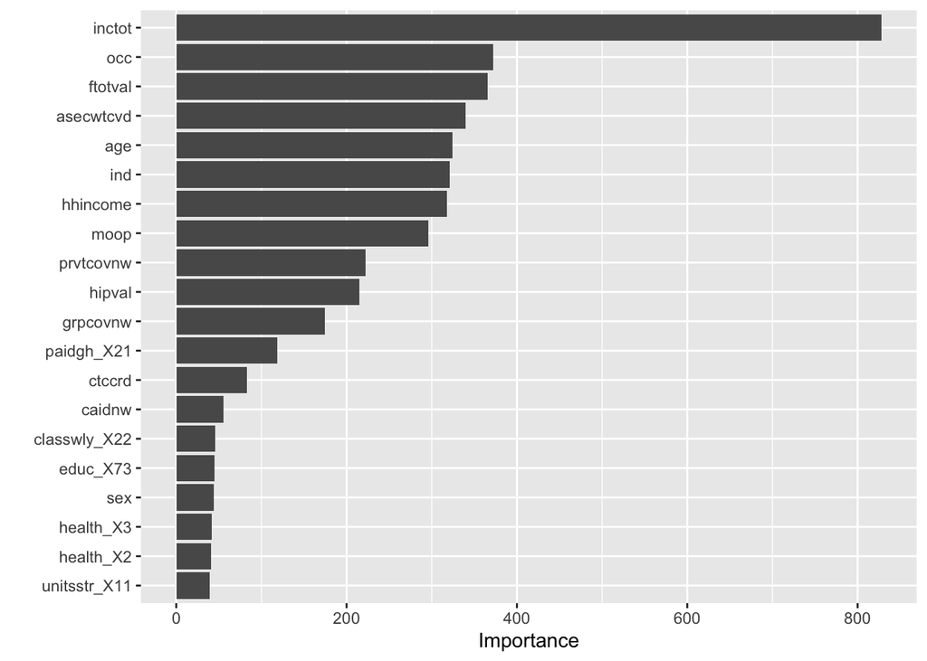

```r
# Look at feature importance
rf_last_fit %>%
  extract_fit_parsnip() %>%
  vip::vip(num_features = 20)
```

The most important features, or predictors, in our model were total income, occupation, total family income, ASEC-COVID weights, age, industry, household income, and total family medical out of pocket payments (in that order). Conceptually, it makes sense that these economical and occupation variables would be most important in predicting employment outcomes. During the pandemic, some industries and occupations were most impacted than others, so it makes sense that occupation and industry could be strong determinants of unemployment.

```r
# Apply model to testing data
rf_predictions <- bind_cols(asec_test,
                            predict(object = rf_last_fit, new_data = asec_test),
                            predict(object = rf_last_fit, new_data = asec_test, type = "prob"))
```

Below we evaluate the performance metrics of the model.

```r
# Assess its performance
conf_mat(data = rf_predictions,
         truth = employed,
         estimate = .pred_class)
```

```
##           Truth
## Prediction     0     1
##          0   878  7366
##          1   416 21849
```

```r
# How often the model is correct (overall)
accuracy(data = rf_predictions,
          truth = employed,
          estimate = .pred_class)
```

```
## # A tibble: 1 × 3
##   .metric  .estimator .estimate
##   <chr>    <chr>          <dbl>
## 1 accuracy binary         0.745
```

```r
# How often the model is correct when a person is actually unemployed
spec(data = rf_predictions,
         truth = employed,
         estimate = .pred_class)
```

```
## # A tibble: 1 × 3
##   .metric .estimator .estimate
##   <chr>   <chr>          <dbl>
## 1 spec    binary         0.748
```

```r
# Our ROC_AUC metric, which also serves as our out-of-sample error rate
roc_auc(data = rf_predictions,
     truth = employed,
     estimate = .pred_0)
```

```
## # A tibble: 1 × 3
##   .metric .estimator .estimate
##   <chr>   <chr>          <dbl>
## 1 roc_auc binary         0.790
```

```r
# Prepare our implementation data
asec2021_models <- as_tibble(asec2021) %>%
  filter(!is.na(employed)) %>%
  mutate(employed = as.factor(employed)) %>% # Make our y variable a factor
  select(-year, -serial, -cpsid, -immigrant) %>% # deselect variables we don't want to include as predictors
  select(-region, -county, -metro, -metarea, -metfips) %>% # deselect most location variables other than county
  select(-empstat, -labforce) %>% # deselect variables that are unuseful (labforce)
  mutate_at(vars(race, unitsstr, citizen, hispan,
                 occ, ind, educ, classwly,
                 strechlk, spmmort, whymove, health, paidgh, statefip), list(~ as.factor(.)))

# Apply model to 2021 data
rf_predictions_2021 <- bind_cols(asec2021_models,
                            predict(object = rf_last_fit, new_data = asec2021_models),
                            predict(object = rf_last_fit, new_data = asec2021_models, type = "prob"))
```

Below we estimate the model’s performance on 2021 data.

```r
# Assess its performance
conf_mat(data = rf_predictions_2021,
         truth = employed,
         estimate = .pred_class)
```

```
##           Truth
## Prediction     0     1
##          0  3003 16762
##          1  1221 51557
```

```r
# How often the model is correct (overall)
accuracy(data = rf_predictions_2021,
         truth = employed,
         estimate = .pred_class)
```

```
## # A tibble: 1 × 3
##   .metric  .estimator .estimate
##   <chr>    <chr>          <dbl>
## 1 accuracy binary         0.752
```

```r
# How often the model is correct when a person is actually unemployed
spec(data = rf_predictions_2021,
     truth = employed,
     estimate = .pred_class)
```

```
## # A tibble: 1 × 3
##   .metric .estimator .estimate
##   <chr>   <chr>          <dbl>
## 1 spec    binary         0.755
```

```r
# Our ROC_AUC metric, which also serves as our out-of-sample error rate
roc_auc(data = rf_predictions_2021,
        truth = employed,
        estimate = .pred_0)
```

```
## # A tibble: 1 × 3
##   .metric .estimator .estimate
##   <chr>   <chr>          <dbl>
## 1 roc_auc binary         0.809
```

### How well does our model perform if applied to specific demographic groups?

While our model fared well enough when we made predictions on IPUMS 2021 data, we wanted to see if the model would perform just as well if we were to restrict the population for which we wanted to predict employment status. We decided to make predictions on a sample of immigrants because we understood immigrants experienced the onset of COVID-19 in nuanced ways. For example, the below graph illustrates surprising find: while it’s well-documented that the US unemployment rate rose during the course of the pandemic, the unemployment rate of US native-born citizens surpassed the rate for immigrants.

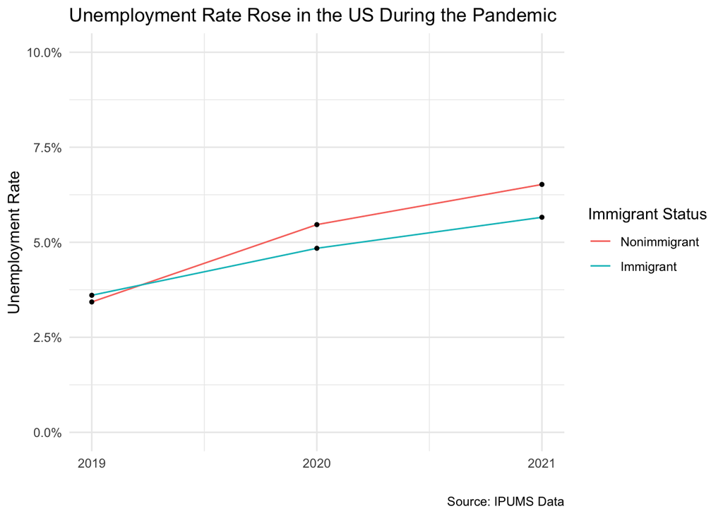

```r
# percentage point change of unemployed people by immigrant status
a <- asec_allyears %>%
  filter(!is.na(employed))%>%
  #filter(year ==2019 | year == 2020) %>% #Including 2021 so we can visualize how unemployment rose for both immigrants and nonimmigrants
  select(year, employed, immigrant) %>%
  group_by(year, immigrant) %>%
  mutate(immigrant = as.factor(immigrant)) %>%
  summarize(count = n(),
            pct_unemployed = (1-mean(employed)))

a %>%
  ggplot(aes(x= year, y= pct_unemployed)) +
  geom_line(aes(color = immigrant, group = immigrant)) +
  geom_point(size = 1) +
   labs(
    title = "Unemployment Rate Rose in the US During the Pandemic",
    caption = "Source: IPUMS Data",
    x = "",
    y = "Unemployment Rate",
    color = "Immigrant Status"
  ) +
  scale_y_continuous(labels = scales::percent, limits = c(0,.10)) +
  scale_x_continuous(breaks = seq(2019, 2021, 1),
                     limits=c(2019, 2021)) +
  scale_color_discrete(labels = c("Nonimmigrant", "Immigrant")) +
  theme_minimal()
```

While we predicted the that it was unlikely that our model trained on a sample representative of US adults in the labor force would perform well on a specific subgroup, we wanted to test it out. Would the model still fare better than random guessing (indicative when the ROC area under the curve is 0.5)? Below we prepare our implementation data.

```r
# Create data frame only of immigrants
asec_model_imm <- as_tibble(asec2021_imm) %>%
  filter(!is.na(employed)) %>%
  mutate(employed = as.factor(employed)) %>% # Make our y variable a factor
  select(-year, -serial, -cpsid, -immigrant) %>% # deselect variables we don't want to include as predictors
  select(-region, -county, -metro, -metarea, -metfips) %>% # deselect most location variables other than county
  select(-empstat, -labforce) %>% # deselect variables that are unuseful (labforce)
  mutate_at(vars(race, unitsstr, citizen, hispan,
                 occ, ind, educ, classwly,
                 strechlk, spmmort, whymove, health, paidgh, statefip), list(~ as.factor(.)))

# Apply model to 2021 immigrant data
rf_predictions_imm <- bind_cols(asec_model_imm,
                                 predict(object = rf_last_fit, new_data = asec_model_imm),
                                 predict(object = rf_last_fit, new_data = asec_model_imm, type = "prob"))
```

Below we estimate the model’s performance on data of immigrants only.

```r
# Assess its performance
conf_mat(data = rf_predictions_imm,
         truth = employed,
         estimate = .pred_class)
```

```
##           Truth
## Prediction     0     1
##          0  2378 12597
##          1   946 42823
```

```r
# How often the model is correct (overall)
accuracy(data = rf_predictions_imm,
         truth = employed,
         estimate = .pred_class)
```

```
## # A tibble: 1 × 3
##   .metric  .estimator .estimate
##   <chr>    <chr>          <dbl>
## 1 accuracy binary         0.769
```

```r
# How often the model is correct when a person is actually unemployed
spec(data = rf_predictions_imm,
     truth = employed,
     estimate = .pred_class)
```

```
## # A tibble: 1 × 3
##   .metric .estimator .estimate
##   <chr>   <chr>          <dbl>
## 1 spec    binary         0.773
```

```r
# Our ROC_AUC metric, which also serves as our out-of-sample error rate
roc_auc(data = rf_predictions_imm,
        truth = employed,
        estimate = .pred_0)
```

```
## # A tibble: 1 × 3
##   .metric .estimator .estimate
##   <chr>   <chr>          <dbl>
## 1 roc_auc binary         0.819
```

Contrary to our expectations, our model could be generalized to an immigrant-only data set. Accuracy, specificity, and area under the curve metrics were even better than previous instances. Since our immigrant-only data set included immigrants of all status (naturalized citizens, Legal Permanent Residents, undocumented immigrants), it is likely that the population was not sufficiently distinguishable enough from the general US population to drive a large difference in model performance.

Overall, we are content with our model’s performance and would deem it a useful tool to predict employment status in the COVID era (understanding that it would need to be retrained and reassessed for its usefulness in future periods).

[^1]: https://www.census.gov/topics/population/foreign-born/guidance/cps-guidance/cps-vs-asec.html
[^2]: Sarah Flood, Miriam King, Renae Rodgers, Steven Ruggles, J. Robert Warren and Michael Westberry. Integrated Public Use Microdata Series, Current Population Survey: Version 9.0 [dataset]. Minneapolis, MN: IPUMS, 2021. https://doi.org/10.18128/D030.V9.0
[^3]: Aaron Klein and Ember Smith. Explaining the Economic Impact of COVID-19: Core Industries and the Hispanic Workforce. Feb. 5, 2021. https://www.brookings.edu/research/explaining-the-economic-impact-of-covid-19-core-industries-and-the-hispanic-workforce/.